# Plot a Batch of Annual Participation Networks

Preparation for network analysis in CCIEA ESR

M. Fisher, J.F. Samhouri

Written Jan. 6, 2021. Last Run 2021-07-04

# Description

Plot a batch of annual fisheries participation networks (from a list of igraph objects) by port group and year. This script uses a circular layout, with network nodes colored according to the gear group used in each fishery. **The nodes are consistently located across plots,** so that plots can be more easily compared through time or across port groups.

This script requires the following packages.

```r
if(!require("tidyverse")) {install.packages("tidyverse")}
if(!require("ggplot2")) {install.packages("ggplot2")}
if(!require("igraph")) {install.packages("igraph")}
if(!require("RColorBrewer")) {install.packages("RColorBrewer")}
if(!require("stringr")) {install.packages("stringr")}
```

And calls the following functions:

```r
source(here::here('R/color_network_nodes.R'))
source(here::here('R/plot_network_bulk_comparable.R'))
```

# User Inputs

Select your directories.

```r
## location of igraph objects
indir = 'data/networks/participation_bulk'

## output directory for network viz
pngdir = 'data/networks/participation_bulk/plots/comparable'
```

Identify the crab years, port groups, and % contributions to port-level bulk revenue that you would like to produce networks for.

```r
## (crab) years
years <- seq(2004,2019)
# years <- 2008 # testing script, 1/6
# years <- 2018 # testing script, 1/8
# years <- 2014 # testing script, 1/27

## port groups
myports <- c("Puget Sound","North WA Coast","WA Coast","Other Coastal Washington","Astoria","Tillamook","Columbia River","Newport","Coos Bay","Brookings","Crescent City","Eureka","Morro Bay","Fort Bragg","Bodega Bay","San Francisco","San Diego","Monterey","Santa Barbara","Los Angeles","Unknown Ports" )
#myports <- c("BDG") # testing script, 1/6
#myports <- c("Columbia River") # testing script for single node networks, 1/7
# myports <- c("Monterey") # testing script, 1/8
# myports <- c("Bodega Bay") # testing script, 1/27/21

## To avoid inclusion of rare or minimal fishing activity, a given fishery must contribute to at least contr_cutoff% of a port's seasonal revenue to be included in the network data. This cutoff value can be increased if more stringent fishery inclusion criteria are preferred, and decreased (i.e. for summaries over shorter temporal / smaller spatial scales).
contr_cutoff <- 0.1
```

# 1: Read in data

Read the igraph objects into a list. This for loop will also apply the functions to recolor and rename vertices

```r
#palette(brewer.pal(n = 10, name = "Set3"))
#pal3 <- brewer.pal(n = 10, name = "Set3")

graphs_list <- list()
graph_names <- c()
i=1
for(p in myports){
  for(y in years){
  #y=2013 # testing script for single node networks, 1/7
  # y=2014 # testing script for single node networks, 1/27
    if(file.exists(here::here(indir, paste0("igraph_", p, "_", y ,"_rmCrab_bulk_",contr_cutoff*100,".rds")))){
      tmpgraph <- readRDS(here::here(indir, paste0("igraph_", p, "_", y ,"_rmCrab_bulk_",contr_cutoff*100,".rds")))
      V(tmpgraph)$p <- p
      V(tmpgraph)$year <- y
      V(tmpgraph)$colors <- vertex_color(tmpgraph)
      graphs_list[[i]] <- tmpgraph
      graph_names[i] <- paste0(p,"_",y)
      i = i + 1
      } else{ y = y +1 }
  }
}
names(graphs_list) <- graph_names
```

# 2: Plot Comparable Networks

This function plots networks using the circular layout, with consistent node placement across plots to allow for visual comparison.

An example of the circular layout:

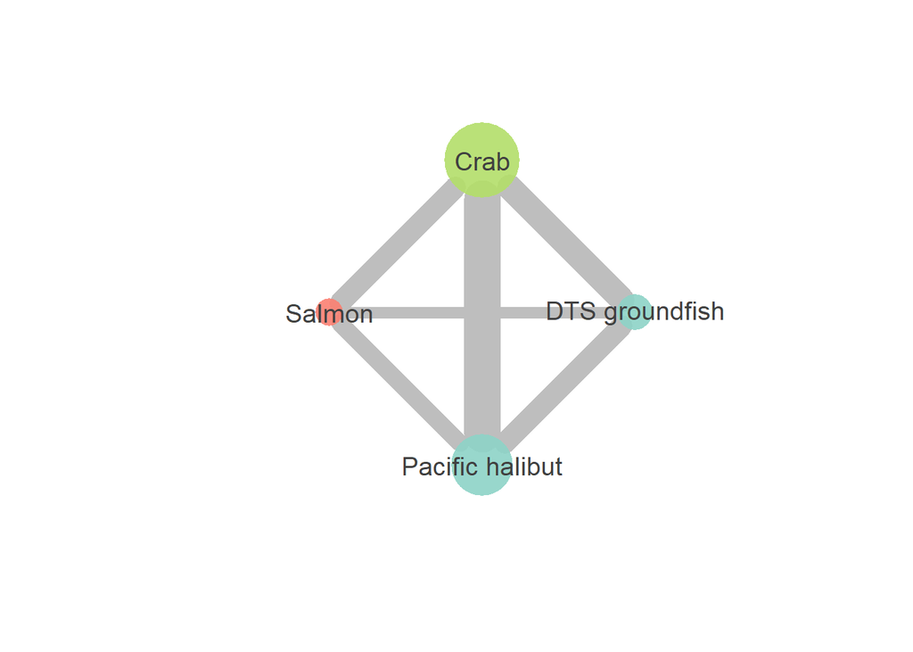

Plots will be written out to .png files in the function. This is because the igraph `plot` function won’t save into an object that can be returned.

```r
glist <- graphs_list[1:25]
plot_comparable_networks(glist, outdir=pngdir)
```

[output not shown]

```
## added 2 empty vertices to graph 2
```

```
## added 3 empty vertices to graph 3
```

```
## added 3 empty vertices to graph 4
```

```
## added 2 empty vertices to graph 5
```

```
## added 3 empty vertices to graph 6
```

```
## added 3 empty vertices to graph 7
```

```
## added 3 empty vertices to graph 8
```

```
## added 4 empty vertices to graph 9
```

```
## added 3 empty vertices to graph 10
```

```
## added 3 empty vertices to graph 11
```

```
## added 5 empty vertices to graph 12
```

```
## added 4 empty vertices to graph 13
```

```
## added 3 empty vertices to graph 14
```

```
## added 5 empty vertices to graph 15
```

```
## added 4 empty vertices to graph 16
```

```
## added 2 empty vertices to graph 17
```

```
## added 3 empty vertices to graph 18
```

```
## added 3 empty vertices to graph 19
```

```
## added 3 empty vertices to graph 20
```

```
## added 3 empty vertices to graph 21
```

```
## added 3 empty vertices to graph 22
```

```
## added 3 empty vertices to graph 23
```

```
## added 3 empty vertices to graph 24
```

```
## added 2 empty vertices to graph 25
```